# Detecting resting behavior of wild boar in GPS data

Patterns and Trends in Environmental Data, MSc ENR, ZHAW

Nina Poglic & Mirjam Kurz

03-07-2022

## Introduction

As GPS technology is advancing, there is a surge in the development of new methods for studying animal movement. One particular interest is to infer animal spatial behavior from movement data.

The spatial behavior of an animal has a wide meaning such as movement, habitat selection, home range, core area, territoriality, and migration. It can be influenced by decisions relating to foraging, movement, avoidance, resting, territorial activity, mating, and rearing young. In movement data, these behaviors can all show specific patterns (Hance et al, 2021). However, it is often the case, that a time series of animal locations is the result of multiple behaviors (Patterson et al, 2009). For example, an animal staying in one place because it is sleeping or moving very slowly while foraging results in a similar static pattern: the distance between consecutive points would be very low. Distinguishing between such similar patterns and concluding on the underlying behavior is a challenge.

In this research project, we attempt to make conclusions about the resting behavior of 19 wild boars based on their movement data. More specifically, we tried finding periods in time when the wild boars did not move quickly, in which they were thus stationary. As it is reported that wild boar sleep around twelve hours per day (Wild Boar – WLS, n.d.), we were interested in the length of the time span in which the monitored animals stayed stationary.

Further, we investigated where the wild boar spend these stationary periods. In general, wild boar prefer broad-leaved forests with older mast species (beech, oak) while foraging, and in contrast, the coniferous forest is preferred for their resting sites as well as secure places for wallowing and sleeping (Erdtmann & Keuling, 2020).

The research questions were thus: • For how long are the monitored wild boar stationary on average? • Where do the wild boar spend these stationary periods?

## Material and Methods

### Study area

The area where the observed wild boar are located includes mostly Gampelen and its surroundings. Gampelen is mostly covered with agricultural land and forest, and lays by the Lake Neuchâtel. At the border of the lake, there are also large areas of wet meadows.

### Home range of animals

[interactive chart not shown]

### Dataset

The GPS data describing the movement of the wild boar was provided by the ZHAW. The dataset contained a total of 327’255 location fix points with the following attributes: *TierID: Animal ID* TierName: Animal name *DatetimeUTC: Date and time* Geometry: location of animal (coordinates) *Day: Category of daytime*  
Day: 8 am – 9.15 pm *Dusk: 9.15 – 10 pm* 1st night quarter: 10 – 11.30 pm *2nd night quarter: 11.30 pm – 1.15 am* 3rd night quarter: 1.15 – 3.30 am *4th night quarter): 3.30 – 5 am* Dawn: 5 – 8 am We did not use the additional information on moon illumination and the collar ID for this project. The data was collected with GPS collars fitted to 19 wild boars. They were programmed to attempt a GPS location fix every 15 minutes. The mean time lag between consecutive points was 17.8 minutes. The total study time lasted for 874 days from the 28th of May 2014 to the 18th of October 2016. However, not all animals were monitored at the same time and some individuals show gaps in their sampling interval (see Figure 2).

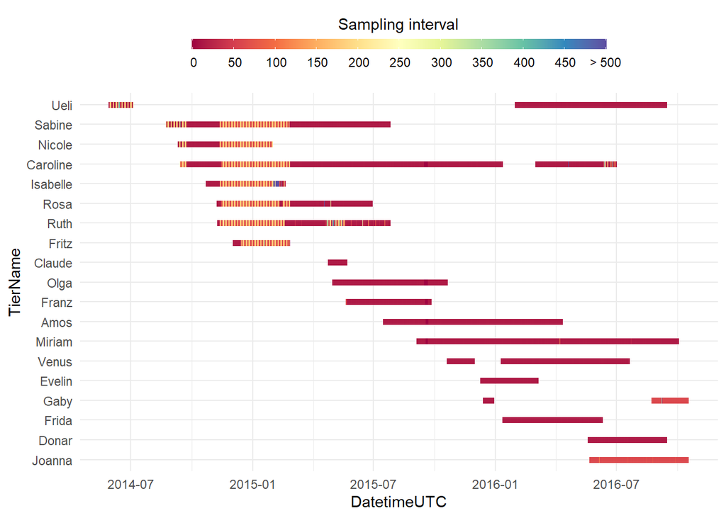

*Figure 2: Sampling regime: Sampling interval and observed time range for each individuals (TierName) during the whole study period.*

In addition, we received a dataset from the ZHAW containing habitat information about the investigates area. This dataset included the factors forest, wet meadow and different types of crops.

### Analysis

We used RStudio 2021.09.0 for all subsequently described analysis. To answer the research question of when the monitored wild boars were stationary, we first calculated the step length for each fix point, meaning the Euclidean distance between consecutive fix points. We then used a temporal window approach as described in Laube & Purves (2011). We tried different window sizes (k) from k = 4 to k = 20, corresponding to time frames of approximately one to five hours considering the mean time lag between consecutive points. Since we were looking for longer stationary periods, we decided to use k = 12 (3 hours) for subsequent analysis. For each temporal window, we calculated the mean step length.

To find stationary time spans in the wild boar movement we needed to define a threshold of mean step length per temporal window. We defined all temporal windows with a mean Euclidian distance of less than 10 m as static. This threshold was chosen due to the approximate accuracy of the GPS device being 10 m. We then joined all consecutive static temporal windows to one segment and removed the non-static segments.

Finally, we calculated the mean time frame of each static segment. The segments were then filtered, and any with lengths of less than two hours were removed as we were interested in long stationary segments.

In order to answer the second research question, we added the habitat information to the filtered stationary segments. We then evaluated in what habitat the stationary segments are located and if any seasonal or daily structure could be observed.

## Results

In a first step, we explored the calculated step lengths. The mean step length of all animals was 39 meters, the median seven meters (see Figure 3).

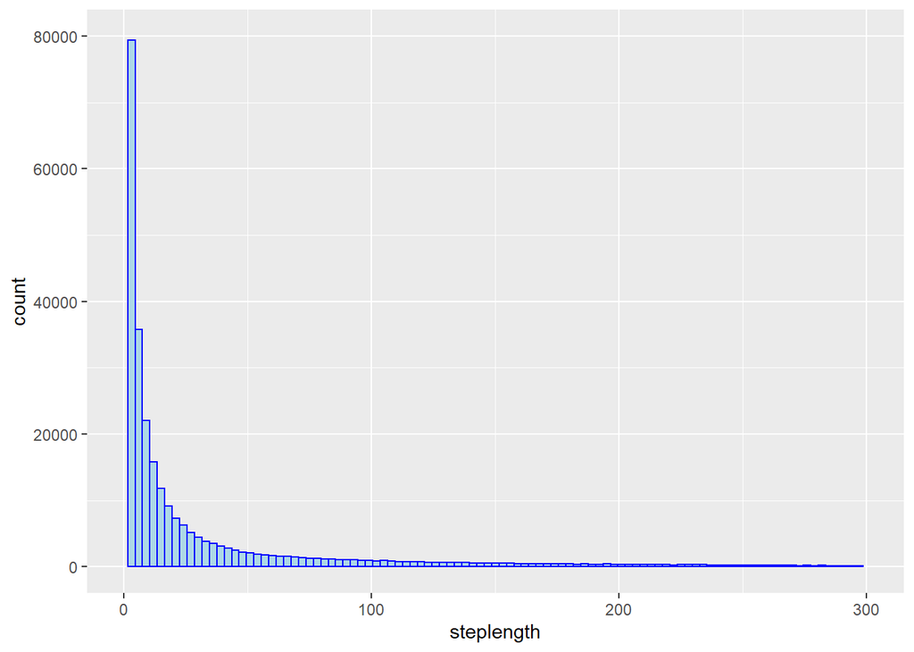

*Figure 3: Distribution of the distance of consecutive points (steplength) of all monitored wild boar.*

We then searched for a period when many animals were monitored at the same time and visualized the steps of these individuals. In Figure 4 the seven chosen individuals (Caroline, Fritz, Isabelle, Nicole, Rosa, Ruth, Sabine) all show a similar step pattern during the first week of January 2015, with more active and more static stretches.

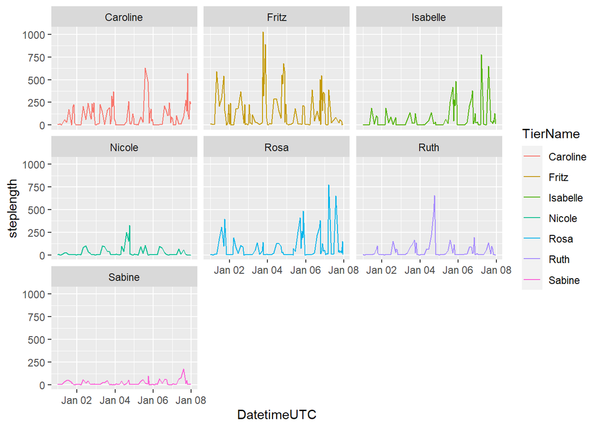

*Figure 4: Distribution over time of the distance of consecutive points (steplength) of seven individuals during the first week of January.*

In a next step, we investigated the time length of the temporal windows defined as stationary. With the chosen parameters of k=12 for the rolling window and maximum 10 m as mean steplength for each rolling window, we found a total of 5385 stationary segments, which corresponds to 48% of all defined segments. After filtering short segments of less than two hours only 3009 stationary segments were left, approximately a third of all defined segments. Their mean time span was 8.5 hours (507 minutes), the median 7.75 hours (465 minutes) (see Figure 5).

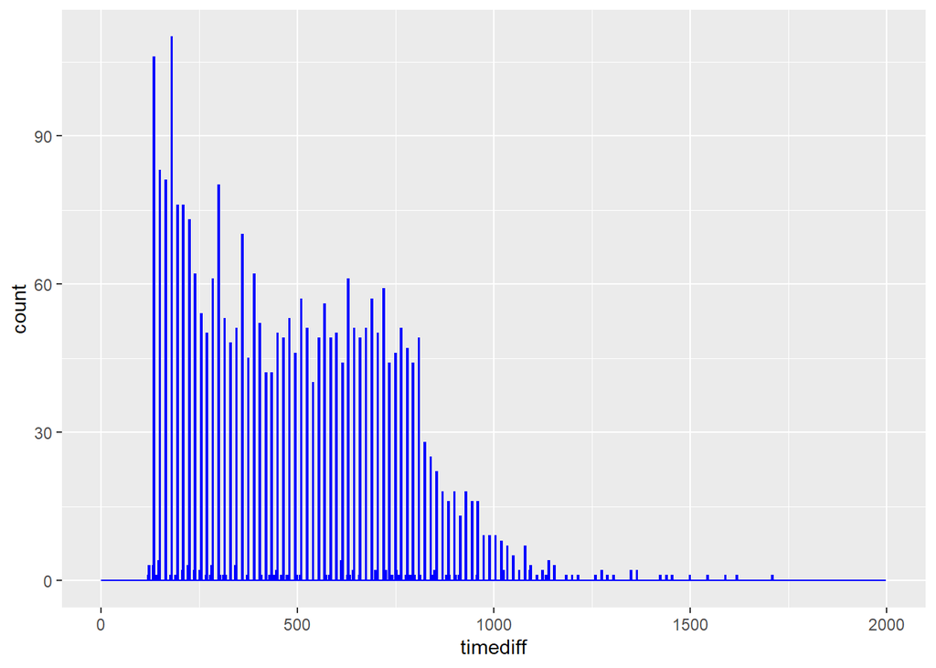

*Figure 5: Time length of stationary segments of all animals after filtering out short segments below 2 hours.*

The mean time length of stationary elements per animal ranged from 187.375 minutes (Joanna) to 823 minutes (Fritz) (Table 2).

Mean time length of stationary segments per individual.

| TierName | name |
| --- | --- |
| Amos | 487.7942 |
| Caroline | 498.5625 |
| Claude | 241.7143 |
| Donar | 486.5317 |
| Evelin | 594.0424 |
| Franz | 434.1888 |
| Frida | 609.0323 |
| Fritz | 823.0000 |
| Gaby | 415.8571 |
| Isabelle | 516.2000 |
| Joanna | 187.3750 |
| Miriam | 602.8244 |
| Nicole | 520.9863 |
| Olga | 453.8954 |
| Rosa | 551.0714 |
| Ruth | 368.8837 |
| Sabine | 438.0442 |
| Ueli | 390.3373 |
| Venus | 506.8524 |

Following this, we looked at the time of day during which these stationary segments were found. The majority of the stationary segments started in between 2 and 6 am and ended between 1 and 4 pm (see Figure 6 & 7).

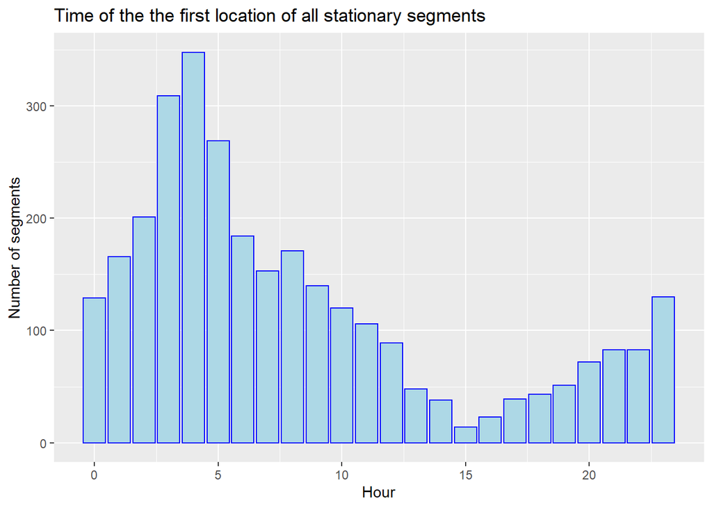

*Figure 6: The hour of the first location of all stationary segments.*

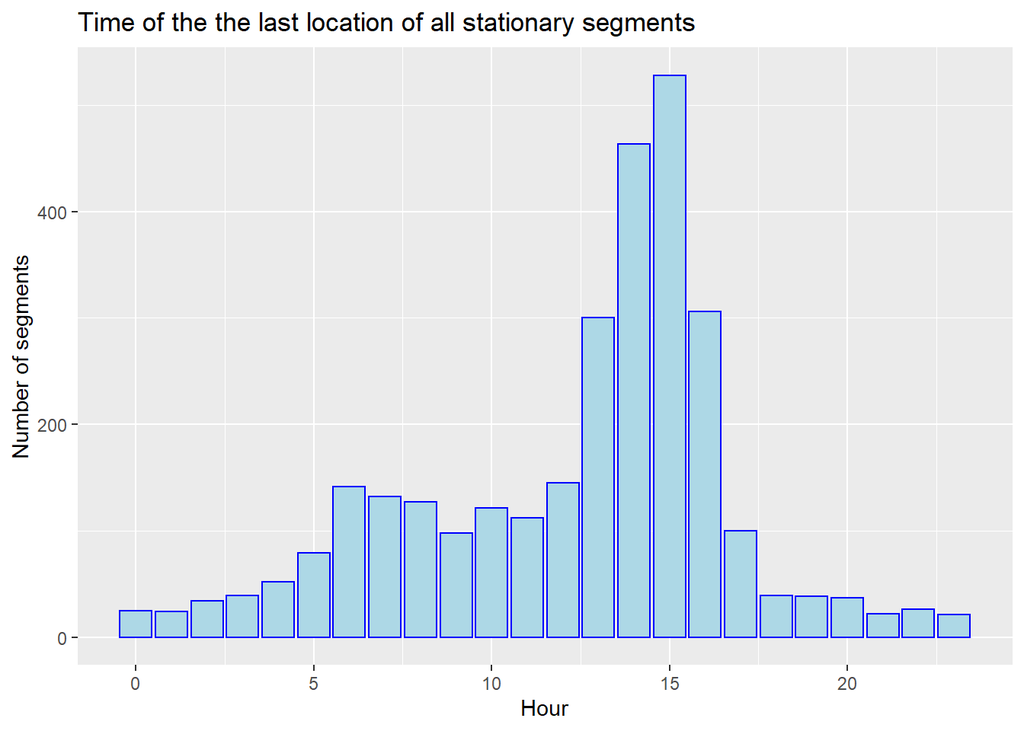

*Figure 7: The hour of the last location of all stationary segments.*

Last but not least, we were interested in the location of the stationary segments.We gave each segment the location of the first point in the segment. Because the sampling time and interval was different for many observed animal, we investigated the four animals, which had the most data points in a first step. These animals were monitored over a five month period (1.1.2015 - 1.5.2015). Figure 8 shows, that the stationary segments are distributed differently for each animal. While Caroline and Rosa stayed staionary all around the observed area, Ruth and Sabine stayed stationary more or less in the same place.

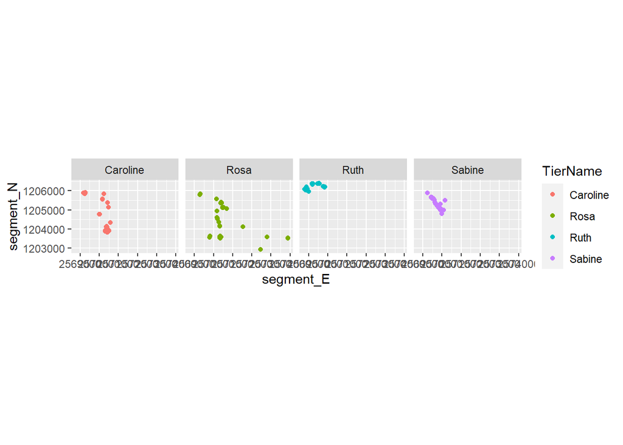

*Figure 8: Location of stationary segments of the four animals with the most data points: Sabine, Caroline, Rosa and Ruth.*

We also added all the stationary segments of all the monitored animals on a map. The majority of the observed wild boar are spending their resting time near the wet meadows or in the woods (figure 9).

[interactive chart not shown]

By adding the habitat of the first point of a segment to the segment, it was confirmed, that most stationary segments were spent in wet meadows (figure 10).

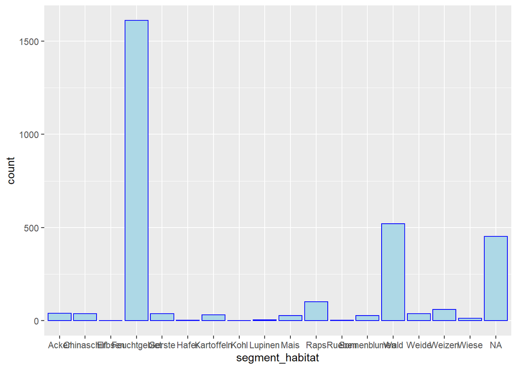

*Figure 10: Habitat type of all stationary segments.*

## Discussion

It’s difficult to link the observed pattern in the GPS data to the behavior of resting. Similar patterns could arise from different behaviors or could be a mixture of multiple behaviors. With our approach inspired by Laube & Purves (2011) we tried differentiating between segments when the animals were walking very slowly or actually staying in one place. However, if the animals move slowly for many hours, the mean of the temporal window would stay just as small as when the animal is staying in one place. The approach described in Hance et al. (2021) could offer a solution to answer our research questions further.

We are also averring of other limits in this research. For example, we used threshold of 10 meters for all temporal windows and define distance below the threshold to be static, which could cut off the data that if included, would make different resultant. Second problem with uncertainty could be the different time intervals of the measurements. Because we calculated the average time lag between consecutive points, the missing intervals could lead to higher or lower mean value. Also, the animal could have moved between the chosen temporal window and the movement wasn’t included in the calculation. Problematic approach in this research could also be that chosen rolling window k12 (3 hours) was based only on our assumption that with this range we will get longer stationary periods. It could be that with different k we would get different results.

The results were slightly undervalued in comperes to the literature research, which stated that wild boars sleep twelve hours. It was shown that observed animals are stationary on average for eight hours, while the minimum time spam was around three hours and maximum was almost fourteen hours. The difference between min and max could probably be attributed to the chosen threshold and the size of the temporal window. We also find that almost 50% of all defined segments were static, and observed that they mostly appear at the night and early in the morning. We were also able to answer second question, where can the static segments be observed. We conform that they are mostly at the wet meadows during their resting time. We could also try to see if their resting behavior change in between seasons, for example if they res longer in the winter. It could also be interesting to see if the hypothesis that resting behavior is mostly after foraging.

## Literature

Erdtmann, D., & Keuling, O. (2020). Behavioural patterns of free roaming wild boar in a spatiotemporal context. PeerJ, 8, e10409. https://doi.org/10.7717/peerj.10409

Hance, D.J., Moriarty, K.M., Hollen, B.A. et al. (2021). Identifying resting locations of a small elusive forest carnivore using a two-stage model accounting for GPS measurement error and hidden behavioral states. Mov Ecol 9, 17 . https://doi.org/10.1186/s40462-021-00256-8

Laube, P. & Purves, R.S. (2011). How fast is a cow? Cross-scale analysis of movement data. Transactions in GIS, 15(3): 401-418. https://doi.org/10.1111/j.1467-9671.2011.01256.x

Thurfjell, H. (n.d.). Spatial Behaviour of Wild Boar. 49.

Patterson TA, Basson M, Bravington MV, Gunn JS. Classifying movement behaviour in relation to environmental conditions using hidden Markov models. J Anim Ecol. 2009;78(6):1113–23. https://doi.org/10.1111/j.1365-2 656.2009.01583.x.

Wild boar – WLS. (n.d.). Retrieved 29 June 2022, from https://wls.ch/wild-boar/?lang=en